# Project 1: Wrangling, Exploration, Visualization

SDS322E

## Data Wrangling, Exploration, Visualization

### Kazuma Hirota, kh37775

#### Introduction

In this project, I chose two datasets found in fivethirtyeight that record the economical data, soccer specific data, and population data for countries that are part of FIFA. The first dataset, “fifa_audience”, records the relative population share, TV audience share, and the GDP share for each country. The shares are calculated in percentage, and the TV audience share is recorded particularly for soccer programs. The second dataset, “elo_blatter”, records the soccer ELO score of each country in 1998 and 2015, which are determined from the national teams’ past performances. The dataset also records the average GDP and the population of each country as well as the sources from which they were acquired. Both datasets are categorized by the confederation based on the continent.

I decided to perform analysis on the mentioned datasets because soccer has been my biggest passion since age 3. I believe that soccer is a sport that can be enjoyed by anyone regardless of race, gender, or socioeconomic status, and I would like to prove this claim through the project by exploring relationships between economy, culture, and the sport of soccer.

```r
library(tidyverse)
library(fivethirtyeightdata)
library(fivethirtyeight)
library(gt)
fifa <- fifa_audience
elo <- elo_blatter
fifa %>% glimpse()
```

```
## Rows: 191
## Columns: 5
## $ country            <chr> "United States", "Japan", "China", "Germany", "Bra…
## $ confederation      <chr> "CONCACAF", "AFC", "AFC", "UEFA", "CONMEBOL", "UEF…
## $ population_share   <dbl> 4.5, 1.9, 19.5, 1.2, 2.8, 0.9, 0.9, 0.9, 2.1, 0.7,…
## $ tv_audience_share  <dbl> 4.3, 4.9, 14.8, 2.9, 7.1, 2.1, 2.1, 2.0, 3.1, 1.8,…
## $ gdp_weighted_share <dbl> 11.3, 9.1, 7.3, 6.3, 5.4, 4.2, 4.0, 4.0, 3.5, 3.1,…
```

```r
elo %>% glimpse()
```

```
## Rows: 209
## Columns: 8
## $ country       <chr> "Afghanistan", "Albania", "Algeria", "Andorra", "Angola…
## $ elo98         <int> 993, 1382, 1486, 1067, 1498, 612, 1149, 1872, 1394, 101…
## $ elo15         <int> 1116, 1549, 1671, 952, 1435, 641, 1264, 2041, 1512, 925…
## $ confederation <chr> "AFC", "UEFA", "CAF", "UEFA", "CAF", "CONCACAF", "CONCA…
## $ gdp06         <dbl> 1076.461, 7181.094, 11093.217, 38800.000, 4996.767, 880…
## $ popu06        <dbl> 25631282, 2992547, 34507214, 81877, 17122409, 13677, 83…
## $ gdp_source    <chr> "World Bank", "World Bank", "World Bank", "CIA (2005)",…
## $ popu_source   <chr> "World Bank", "World Bank", "World Bank", "World Bank",…
```

#### Tidying: Reshaping

```r
fifa <- fifa %>% pivot_wider(names_from = confederation, values_from = confederation)
fifa <- fifa %>% pivot_longer(cols = 5:10, values_to = "confederation") %>%
    select(-name) %>% na.omit()
fifa <- fifa[, c(1, 5, 2, 3, 4)]
```

Here, I expanded the fifa dataset to make each confederation a column, which would show NA if the country does not belong to the confederation. Then, used pivot_longer to tidy the dataset and deleted the name column. Finally, I omitted all of the NAs and reorganized the columns to rearrange the dataset back to its original form. I will perform more tidying in the visualization section.

#### Joining/Merging

```r
# perform full join
joined_fifa <- fifa %>% full_join(elo, by = c("country", "confederation"))
glimpse(joined_fifa)
```

```
## Rows: 233
## Columns: 11
## $ country            <chr> "United States", "Japan", "China", "Germany", "Bra…
## $ confederation      <chr> "CONCACAF", "AFC", "AFC", "UEFA", "CONMEBOL", "UEF…
## $ population_share   <dbl> 4.5, 1.9, 19.5, 1.2, 2.8, 0.9, 0.9, 0.9, 2.1, 0.7,…
## $ tv_audience_share  <dbl> 4.3, 4.9, 14.8, 2.9, 7.1, 2.1, 2.1, 2.0, 3.1, 1.8,…
## $ gdp_weighted_share <dbl> 11.3, 9.1, 7.3, 6.3, 5.4, 4.2, 4.0, 4.0, 3.5, 3.1,…
## $ elo98              <int> 1730, 1710, 1631, 2023, 2065, NA, 1929, 1963, 1814…
## $ elo15              <int> 1804, 1755, 1588, 2104, 2036, NA, 1853, 1931, 1741…
## $ gdp06              <dbl> 46437.107, 31790.650, 5724.917, 34667.649, 11181.5…
## $ popu06             <dbl> 298379912, 127854000, 1311020000, 82376451, 188134…
## $ gdp_source         <chr> "World Bank", "World Bank", "World Bank", "World B…
## $ popu_source        <chr> "World Bank", "World Bank", "World Bank", "World B…
```

The original fifa dataset contains 191 rows and 5 columns, and the original elo dataset contains 209 rows and 8 columns. I performed a full join of the fifa dataset and the elo dataset by “country” and “confederation”. I did a full join so that I can determine which countries are unique to each of the datasets and so that I would not lose any data.

```r
# determine which countries have multiple rows
joined_fifa %>% count(country) %>% filter(n > 1)
```

```
## # A tibble: 2 x 2
##   country     n
##   <chr>   <int>
## 1 Tunisia     2
## 2 Yemen       2
```

```r
joined_fifa %>% filter(country == "Yemen" | country == "Tunisia") %>%
    select(country, confederation)
```

```
## # A tibble: 4 x 2
##   country confederation
##   <chr>   <chr>
## 1 Yemen   CAF
## 2 Tunisia AFC
## 3 Tunisia CAF
## 4 Yemen   AFC
```

```r
# revise the original dataset
fifa$confederation[fifa$country == "Yemen"] <- "AFC"
fifa$confederation[fifa$country == "Tunisia"] <- "CAF"
```

The joined data has 233 rows and 11 columns, and there are a total of 231 unique countries. Tunisia and Yemen had different confederation labels between the two datasets. Since the confederation for Tunisia and Yemen were mislabeled in the fifa dataset, I revised the values on the fifa dataset and performed a full join again. The resulting dataset contained 231 rows and 11 columns, which contains a row for each unique country.

```r
# perform full join again and replace the dataset
joined_fifa <- fifa %>% full_join(elo, by = c("country", "confederation"))
glimpse(joined_fifa)
```

```
## Rows: 231
## Columns: 11
## $ country            <chr> "United States", "Japan", "China", "Germany", "Bra…
## $ confederation      <chr> "CONCACAF", "AFC", "AFC", "UEFA", "CONMEBOL", "UEF…
## $ population_share   <dbl> 4.5, 1.9, 19.5, 1.2, 2.8, 0.9, 0.9, 0.9, 2.1, 0.7,…
## $ tv_audience_share  <dbl> 4.3, 4.9, 14.8, 2.9, 7.1, 2.1, 2.1, 2.0, 3.1, 1.8,…
## $ gdp_weighted_share <dbl> 11.3, 9.1, 7.3, 6.3, 5.4, 4.2, 4.0, 4.0, 3.5, 3.1,…
## $ elo98              <int> 1730, 1710, 1631, 2023, 2065, NA, 1929, 1963, 1814…
## $ elo15              <int> 1804, 1755, 1588, 2104, 2036, NA, 1853, 1931, 1741…
## $ gdp06              <dbl> 46437.107, 31790.650, 5724.917, 34667.649, 11181.5…
## $ popu06             <dbl> 298379912, 127854000, 1311020000, 82376451, 188134…
## $ gdp_source         <chr> "World Bank", "World Bank", "World Bank", "World B…
## $ popu_source        <chr> "World Bank", "World Bank", "World Bank", "World B…
```

```r
# determine which countries are shared and which are unique
fifa %>% filter(country %in% elo$country) %>% summarize(n = n())
```

```
## # A tibble: 1 x 1
##       n
##   <int>
## 1   169
```

```r
fifa %>% filter(!country %in% elo$country) %>% summarize(n = n())
```

```
## # A tibble: 1 x 1
##       n
##   <int>
## 1    22
```

```r
elo %>% filter(!country %in% fifa$country) %>% summarize(n = n())
```

```
## # A tibble: 1 x 1
##       n
##   <int>
## 1    40
```

```r
169 + 22 + 40
```

```
## [1] 231
```

```r
# determine which countries are unique
fifa %>% filter(!country %in% elo$country)
```

```
## # A tibble: 22 x 5
##    country     confederation population_share tv_audience_share gdp_weighted_sh…
##    <chr>       <chr>                    <dbl>             <dbl>            <dbl>
##  1 United Kin… UEFA                       0.9               2.1              4.2
##  2 Czech Repu… UEFA                       0.2               0.3              0.5
##  3 Dominica R… CONCACAF                   0.1               0.2              0.1
##  4 Bosnia-Her… UEFA                       0.1               0.1              0.1
##  5 Macau       AFC                        0                 0                0.1
##  6 Trinidad &… CONCACAF                   0                 0                0
##  7 Kosovo      UEFA                       0                 0.1              0
##  8 Suriname    CONCACAF                   0                 0                0
##  9 Turks & Ca… CONCACAF                   0                 0                0
## 10 Congo DR    CAF                        0.9               0.2              0
## # … with 12 more rows
```

```r
elo %>% filter(!country %in% fifa$country)
```

```
## # A tibble: 40 x 8
##    country        elo98 elo15 confederation  gdp06 popu06 gdp_source popu_source
##    <chr>          <int> <int> <chr>          <dbl>  <dbl> <chr>      <chr>
##  1 Andorra         1067   952 UEFA          38800  8.19e4 CIA (2005) World Bank
##  2 Anguilla         612   641 CONCACAF       8800  1.37e4 CIA (2004) CIA (2007)
##  3 Antigua and B…  1149  1264 CONCACAF      22040. 8.35e4 World Bank World Bank
##  4 Belize           985  1098 CONCACAF       7672. 2.79e5 World Bank World Bank
##  5 Bhutan           640   611 AFC            4375. 6.66e5 World Bank World Bank
##  6 Bosnia and He…  1556  1694 UEFA           7087. 3.88e6 World Bank World Bank
##  7 British Virgi…   848   652 CONCACAF      38500  2.35e4 CIA (2004) CIA (2007)
##  8 Comoros          891   907 CAF            1328. 6.17e5 World Bank World Bank
##  9 Congo           1484  1440 CAF            4715. 3.65e6 World Bank World Bank
## 10 Czechia         1853  1752 UEFA          24416. 1.02e7 World Bank World Bank
## # … with 30 more rows
```

Out of the 231 countries, 169 countries are shared between the two datasets. The fifa dataset contains 22 unique countries, and the elo dataset contains 40 unique countries. Since I performed full join, no data was lost during the process. The number of shared countries plus the number of unique countries for each dataset equals the total observations in the joined dataset (169+22+40=231). The countries that are unique to each dataset can be observed above. For example, in the fifa dataset, there is a country called “United Kingdom”, but in the elo dataset, they separated it into “England”, “Scotland”, “Northern Ireland”, and “Wales”.

#### Wrangling

```r
joined_fifa_df <- joined_fifa %>% mutate(tv_audience_per_capita = tv_audience_share/population_share)

joined_fifa_df %>% filter(population_share >= 0.5) %>% arrange(desc(tv_audience_per_capita)) %>%
    select(country, tv_audience_per_capita) %>% slice(1:5) %>%
    gt()
```

| country | tv_audience_per_capita |
| --- | --- |
| Japan | 2.578947 |
| Spain | 2.571429 |
| South Korea | 2.571429 |
| Brazil | 2.535714 |
| Argentina | 2.500000 |

I created a new variable called tv_audience_per_capita by dividing the tv audience share percentage by the population share. Some countries have a very small population share and the value is rounded to the tenths place, so I only considered the “major” countries that have population share of 0.5 or more for this analysis. This is because some countries have a population share value of 0, which would result in an infinity for TV audience per capita, and many countries have a population share of 0.1, which could be very different from the true population share since the values are rounded. Out of the 39 “major” countries considered, Japan had the highest viewers per capita, followed by Spain and South Korea.

```r
calc_increase <- function(x, y) {
    x - y
}
joined_fifa_df %>% na.omit() %>% group_by(confederation) %>%
    summarize(mean_increase = mean(calc_increase(elo15, elo98))) %>%
    gt() %>% tab_header(title = "ELO Increase")
```

ELO Increase

| confederation | mean_increase |
| --- | --- |
| AFC | -40.542857 |
| CAF | -3.270270 |
| CONCACAF | 70.000000 |
| CONMEBOL | 106.200000 |
| OFC | 34.500000 |
| UEFA | 3.297297 |

```r
joined_fifa_df <- joined_fifa_df %>% na.omit() %>% mutate(elo_increase = calc_increase(elo15,
    elo98))
```

Next, I created a function to calculate the change in ELO score between 1998 and 2015. I calculated the average ELO increase for each confederation. The CONMEBOL had the largest average increase, and AFC had the lowest average increase in ELO over the 17 years. ELO scores are ratings of each country’s national soccer team, and the higher ELO score means a stronger team. Countries in UEFA, which are considered to be the greatest countries in the world for soccer, did not have a significant ELO score increase because they have traditionally been the best as well. Countries in CONMEBOL have improved significantly since 1998.

```r
# Mean, Standard Deviation, and Variance for population share
# in total and by continent
joined_fifa_df %>% na.omit() %>% summarize(mean = mean(population_share),
    sd = sd(population_share), variance = var(population_share),
    total_share = sum(population_share), max = max(population_share),
    min = min(population_share)) %>% gt() %>% tab_header(title = "Population Share Analysis")
```

Population Share Analysis

| mean | sd | variance | total_share | max | min |
| --- | --- | --- | --- | --- | --- |
| 0.7330827 | 2.317807 | 5.372231 | 97.5 | 19.5 | 0 |

```r
joined_fifa_df %>% na.omit() %>% group_by(confederation) %>%
    summarize(n = n(), mean = mean(population_share), sd = sd(population_share),
        variance = var(population_share), total_share = sum(population_share),
        max = max(population_share), min = min(population_share)) %>%
    gt() %>% tab_header(title = "Population Share Analysis",
    subtitle = "by Continent")
```

Population Share Analysis

by Continent

| confederation | n | mean | sd | variance | total_share | max | min |
| --- | --- | --- | --- | --- | --- | --- | --- |
| AFC | 35 | 1.6857143 | 4.2918625 | 18.4200840 | 59.0 | 19.5 | 0.0 |
| CAF | 37 | 0.3729730 | 0.4259947 | 0.1814715 | 13.8 | 2.3 | 0.1 |
| CONCACAF | 12 | 0.6416667 | 1.2999709 | 1.6899242 | 7.7 | 4.5 | 0.0 |
| CONMEBOL | 10 | 0.5600000 | 0.8181279 | 0.6693333 | 5.6 | 2.8 | 0.0 |
| OFC | 2 | 0.1000000 | 0.0000000 | 0.0000000 | 0.2 | 0.1 | 0.1 |
| UEFA | 37 | 0.3027027 | 0.4437758 | 0.1969369 | 11.2 | 2.1 | 0.0 |

```r
joined_fifa_df %>% arrange(desc(population_share)) %>% select(country) %>%
    slice(1:3) %>% gt() %>% tab_header(title = "Highest Population Share")
```

Highest Population Share

| country |
| --- |
| China |
| India |
| United States |

I performed statistical analysis of population share both in total and by continent. AFC has the highest population share by continent, mean population share by country, and the max population share of all countries, which is China. The three countries with the highest population share are China, India, and United States, respectively.

```r
# TV share for each continent
joined_fifa_df %>% na.omit() %>% summarize(n = n(), mean = mean(tv_audience_share),
    sd = sd(tv_audience_share), variance = var(tv_audience_share),
    total_share = sum(tv_audience_share), max = max(tv_audience_share),
    min = min(tv_audience_share)) %>% gt() %>% tab_header(title = "TV Audience Share Analysis")
```

TV Audience Share Analysis

| n | mean | sd | variance | total_share | max | min |
| --- | --- | --- | --- | --- | --- | --- |
| 133 | 0.7285714 | 1.688355 | 2.850541 | 96.9 | 14.8 | 0 |

```r
joined_fifa_df %>% na.omit() %>% group_by(confederation) %>%
    summarize(n = n(), mean = mean(tv_audience_share), sd = sd(tv_audience_share),
        variance = var(tv_audience_share), total_share = sum(tv_audience_share),
        max = max(tv_audience_share), min = min(tv_audience_share)) %>%
    gt() %>% tab_header(title = "TV Audience Share Analysis",
    subtitle = "by Continent")
```

TV Audience Share Analysis

by Continent

| confederation | n | mean | sd | variance | total_share | max | min |
| --- | --- | --- | --- | --- | --- | --- | --- |
| AFC | 35 | 1.2285714 | 2.7551632 | 7.5909244 | 43.0 | 14.8 | 0.1 |
| CAF | 37 | 0.2162162 | 0.4740567 | 0.2247297 | 8.0 | 2.6 | 0.0 |
| CONCACAF | 12 | 0.8000000 | 1.4025950 | 1.9672727 | 9.6 | 4.3 | 0.1 |
| CONMEBOL | 10 | 1.3500000 | 2.0897900 | 4.3672222 | 13.5 | 7.1 | 0.1 |
| OFC | 2 | 0.1000000 | 0.0000000 | 0.0000000 | 0.2 | 0.1 | 0.1 |
| UEFA | 37 | 0.6108108 | 0.8408936 | 0.7071021 | 22.6 | 3.1 | 0.0 |

Similar to population share, the AFC has the highest TV audience share. However, the value of the total audience share is much lower than the total population share for AFC. Furthermore, even though CONMEBOL only covers 5.6% of the population share, they cover 13.5% of the TV Audience share. CONMEBOL also has the highest average TV audience share, defeating AFC in the category despite AFC having three times the average population share. Combined with CONMEBOL’s rapid increase in the ELO score over the years, countries in CONMEBOL seem to be very passionate about the sport when compared to other confederations.

```r
joined_fifa_df %>% na.omit() %>% summarize(`ELO98 and ELO15` = cor(elo98,
    elo15)) %>% gt()
```

| ELO98 and ELO15 |
| --- |
| 0.8890522 |

```r
joined_fifa_df %>% na.omit() %>% summarize(`GDP Share and GDP06` = cor(gdp_weighted_share,
    gdp06), `GDP Share and Population` = cor(gdp_weighted_share,
    popu06)) %>% gt()
```

| GDP Share and GDP06 | GDP Share and Population |
| --- | --- |
| 0.3426414 | 0.4398498 |

Next, I explored the correlation between multiple variables. As expected, elo98 and elo15 have a strong correlation because many countries do not drastically improve or worsen in soccer over less than two decades. The surprising finding was that GDP share and population did not have as strong of a correlation as I expected. This means that countries with high population may have a low average individual income, therefore leading to a lower than expected total GDP share. Furthermore, GDP share and average GDP also did not have a strong correlation. This is more understandable because smaller countries may have a high individual income (average GDP), but the overall GDP share might be low due to the population.

```r
joined_fifa_df <- joined_fifa_df %>% mutate(gdp_source = str_replace_all(gdp_source,
    "World Bank.*", "World Bank"), popu_source = str_replace_all(popu_source,
    "World Bank.*", "World Bank")) %>% mutate(gdp_source = str_replace_all(gdp_source,
    "CIA.*", "CIA"), popu_source = str_replace_all(popu_source,
    "CIA.*", "CIA"))

joined_fifa_df %>% na.omit() %>% group_by(confederation, popu_source) %>%
    summarize(n = n())
```

```
## # A tibble: 7 x 3
## # Groups:   confederation [6]
##   confederation popu_source     n
##   <chr>         <chr>       <int>
## 1 AFC           IMF             1
## 2 AFC           World Bank     34
## 3 CAF           World Bank     37
## 4 CONCACAF      World Bank     12
## 5 CONMEBOL      World Bank     10
## 6 OFC           World Bank      2
## 7 UEFA          World Bank     37
```

```r
joined_fifa_df %>% na.omit() %>% group_by(confederation, gdp_source) %>%
    summarize(n = n())
```

```
## # A tibble: 10 x 3
## # Groups:   confederation [6]
##    confederation gdp_source     n
##    <chr>         <chr>      <int>
##  1 AFC           CIA            1
##  2 AFC           IMF            3
##  3 AFC           World Bank    31
##  4 CAF           CIA            1
##  5 CAF           World Bank    36
##  6 CONCACAF      World Bank    12
##  7 CONMEBOL      IMF            1
##  8 CONMEBOL      World Bank     9
##  9 OFC           World Bank     2
## 10 UEFA          World Bank    37
```

Finally, I performed string operations using Regex to eradicate the differences between inputs. For instance, some inputs had the years attached to the names of the sources while others did not. I used str_replace_all to replace the sources with anything attached to just include the name of the source. Then, I created a table grouped by confederation and the source. For both GDP source and population source, most of the data comes from the World Bank.

#### Visualizing

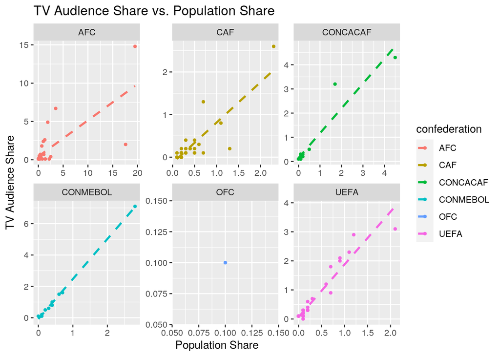

```r
joined_fifa_df %>% group_by(confederation) %>% ggplot(aes(x = population_share,
    y = tv_audience_share, color = confederation)) + geom_point(size = 1) +
    facet_wrap(~confederation, scales = "free") + geom_smooth(method = "lm",
    lty = 2, se = FALSE) + labs(title = "TV Audience Share vs. Population Share",
    x = "Population Share", y = "TV Audience Share")
```

For each continent, I plotted the population share on the x axis and TV audience share on the y axis to visualize which continent has the highest percentage of soccer viewers. When looking at these plots, we must keep in mind that the x and y scales are different for each plot and with each other. From the trendlines, we can observe that CONMEBOL has the largest soccer fanbase by percentage, for the slope of the trendline is around 2.5. This means that relative to the rest of the world, 2.5 times more people watch soccer on average in South America per capita. On the other hand, AFC has the smallest soccer fanbase by percentage. The slope of the trendline for AFC is around 0.5, meaning that the amount of soccer viewers in Asia per capita is half of the rest of the world. Although I analyzed the TV audience per capita briefly in the earlier section, I was not able to analyze using the full dataset because many countries had very small shares while the resolution was relatively large, which interfered with the calculations. Through these plots, I was able to examine the TV audience per capita for each continent using all of the data available for more accurate analysis.

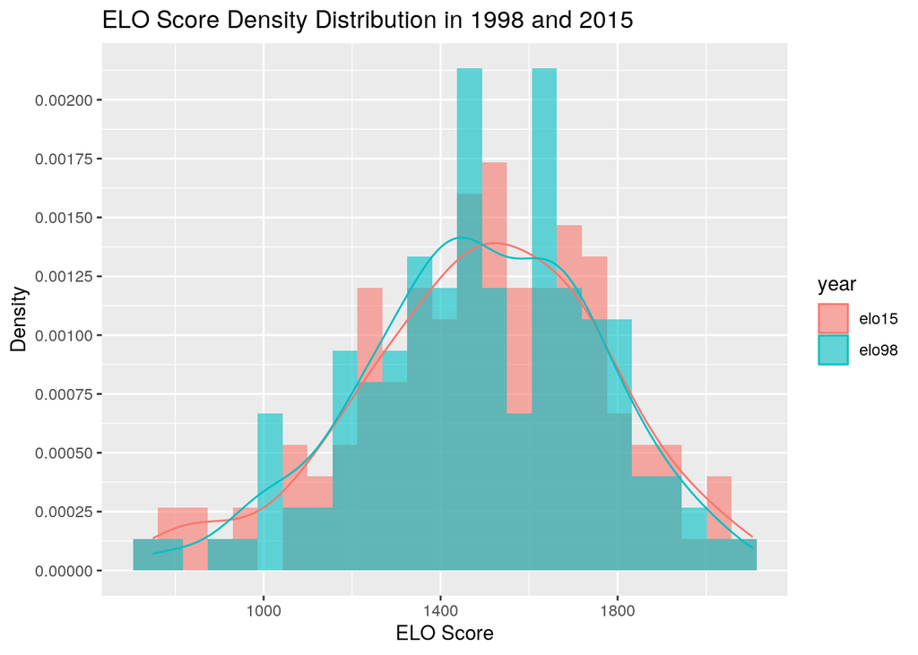

```r
gather(joined_fifa_df, key = year, value = score, c("elo98",
    "elo15")) %>% ggplot(aes(x = score, ..density.., fill = year)) +
    geom_histogram(position = "identity", bins = 25, alpha = 0.6) +
    geom_density(aes(score, color = year), alpha = 0) + labs(title = "ELO Score Density Distribution in 1998 and 2015",
    x = "ELO Score", y = "Density") + scale_y_continuous(breaks = seq(0,
    0.002, 0.00025))
```

In this plot, I visualized the change in overall ELO score distribution from 1998 to 2015. I reshaped the dataset to make it more tidy, using gather() to get rid of the columns elo98 and elo15. As seen in the graph, the two density distribution plots are very similar, but the density plot in 2015 slightly shifted to the right overall. In the earlier section, I determined that the CONMEBOL had the greatest increase in ELO score over the 17 years by over 100 points in average, and AFC decreased their average score by around 40 points. Although all confederations except for two increased their ELO score between 1998 and 2015, the overall ELO score distribution did not change as much. This occurence can be attributed to the fact that the two confederations that decreased in ELO score are AFC and CAF, which are both larger confederations with more countries when compared to confederations such as OFC and CONMEBOL.

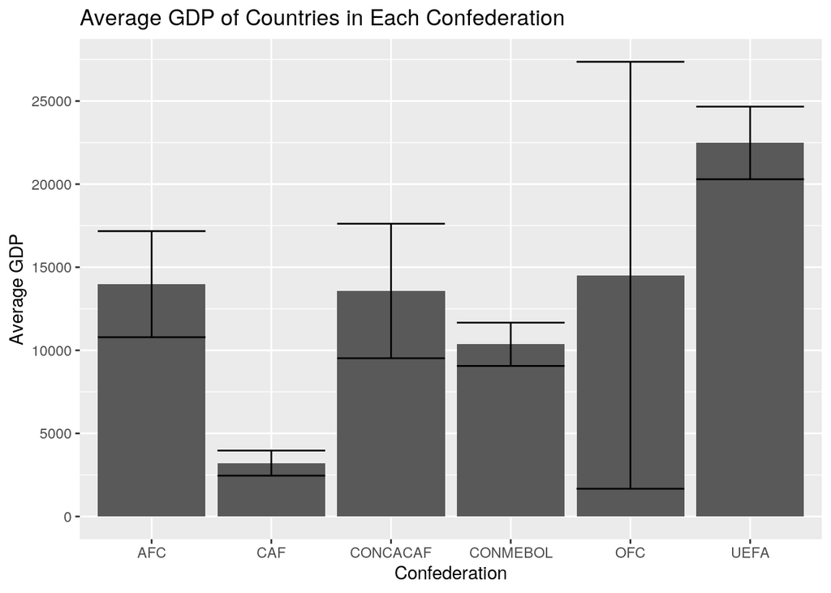

```r
joined_fifa_df %>% ggplot(aes(x = confederation, y = gdp06)) +
    geom_bar(stat = "summary", fun = mean) + geom_errorbar(stat = "summary",
    fun.data = mean_se) + labs(title = "Average GDP of Countries in Each Confederation",
    x = "Confederation", y = "Average GDP") + scale_y_continuous(breaks = seq(0,
    30000, 5000))
```

#### Concluding Remarks

As I initially hypothesized, there is not a strong relationship between a country’s economy and the country’s interest and ability in the sport of soccer. CONMEBOL, which is a confederation based in South America, had one of the lowest average GDPs, but its ELO score and the people’s passion for the sport were among the higest in the world. There is a reason why soccer is called the “beautiful sport”, and I believe one of the reasons is because it can be enjoyed by anyone. Soccer does not require many additional equipments or expensive gears, and it will continue to be the most popular sport in the world.